# Word cloud

Sam Chamberlain

June 30, 2017

## Word cloud for dissertation

Just some standard time wasting to mine what the themes of my research really are. Maybe I’ll learn something about what words I use too much as well. Here are the packages we are using…

```r
#Load packages
library(tm)
library(SnowballC)
library(wordcloud)
library(RColorBrewer)
```

## Load dissertation file and complete basic data cleaning

Save your word file to the R directory and load it with the command prompt that follows. For now, re-save your document as a .txt file. Handling .docx will come in revision

```r
path <- getwd() #get path name
file <- list.files(pattern = "\\.txt$") #find the .txt file name
file_path <- paste(path, file, sep="/")

#now read in the txt file
text <- readLines(file_path)
```

Now your document is loaded to the global environment as the object *text*. In the next step, we load this as a *Corpus* list that can be cleaned to equivalent strings

```r
docs <- Corpus(VectorSource(text))
```

Now that the dissertation is loaded as a Corpus list for each page, we can normalize the strings so uppercase letters are converted to lower case, common words are removed, numbers, etc. These transformations use the *tm* package

```r
docs <- tm_map(docs, stripWhitespace)  #remove extra whitespace
docs <- tm_map(docs, content_transformer(tolower)) #convert to lower case
docs <- tm_map(docs, removeNumbers) #remove nums
docs <- tm_map(docs, removeWords, stopwords("english")) # remove common english
docs <- tm_map(docs, removePunctuation) #remove punctuation
```

## Build a term document matrix

This will mine the text and give you the number of occurences for each word. This section will give you the data matrix required for the *wordcloud* function,

```r
dtm <- TermDocumentMatrix(docs)
m <- as.matrix(dtm)
v <- sort(rowSums(m),decreasing=TRUE)
d <- data.frame(word = names(v),freq=v)
```

… and here are the ten most common words

```
##                word freq
## emissions emissions  253
## water         water  230
## fluxes       fluxes  226
## gas             gas  198
## pasture     pasture  180
## figure       figure  147
## pastures   pastures  128
## surface     surface  119
## table         table  117
## methane     methane  109
```

In my example, the word ‘figure’ appears in the top ten, which should not be there as it is a consequence of science writing rather than content. Also, ‘water table’ is split, so let’s drop ‘table’ as well. Change is according to your own analysis. So let’s remove that as well and rebuild the matrix.

```r
docs <- tm_map(docs, removeWords, c("figure", "table"))

#Now rebuild the matrix
dtm <- TermDocumentMatrix(docs)
m <- as.matrix(dtm)
v <- sort(rowSums(m),decreasing=TRUE)
d <- data.frame(word = names(v),freq=v)
```

Let’s check it again…

```
##                word freq
## emissions emissions  253
## water         water  230
## fluxes       fluxes  226
## gas             gas  198
## pasture     pasture  180
## pastures   pastures  128
## surface     surface  119
## methane     methane  109
## cattle       cattle  101
## soil           soil   98
```

## Word cloud

Finally, we can build the cloud using the following code

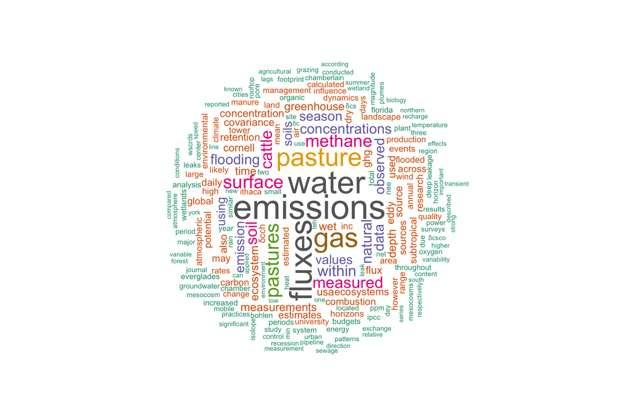

```r
set.seed(1234)
wordcloud(words = d$word, freq = d$freq, min.freq = 1,
          max.words=200, random.order=FALSE, rot.per=0.35,
          colors=brewer.pal(8, "Dark2"))
```